# Bayesian Networks in Formula One Race Strategy

2023 season

Natalia Kortals

2024-10-23

Firstly, we load the data saved into .csv file, acquired using f1dataR package. https://CRAN.R-project.org/package=f1dataR

```r
folder_path <- "data/"

file_list <- list.files(path = folder_path, pattern = "2023\\.csv$", full.names = TRUE)
file_list
```

```
##  [1] "data/albert_park2023.csv"   "data/americas2023.csv"
##  [3] "data/bahrain2023.csv"       "data/baku2023.csv"
##  [5] "data/catalunya2023.csv"     "data/hungaroring2023.csv"
##  [7] "data/interlagos2023.csv"    "data/jeddah2023.csv"
##  [9] "data/losail2023.csv"        "data/marina_bay2023.csv"
## [11] "data/miami2023.csv"         "data/monaco2023.csv"
## [13] "data/monza2023.csv"         "data/red_bull_ring2023.csv"
## [15] "data/rodriguez2023.csv"     "data/silverstone2023.csv"
## [17] "data/spa2023.csv"           "data/suzuka2023.csv"
## [19] "data/vegas2023.csv"         "data/villeneuve2023.csv"
## [21] "data/yas_marina2023.csv"    "data/zandvoort2023.csv"
```

```r
season_df <- data.frame()
for (file in file_list) {
  temp_df <- read.csv(file)
  # add a variable event that will be useful for filtering                                                                     through races
  temp_df$event <- gsub("2023", "", tools::file_path_sans_ext(basename(file)))
  season_df <- rbind(season_df, temp_df)
}
```

```r
print(dim(season_df))
```

```
## [1] 24431    20
```

```r
head(season_df)
```

```
##   X driver lap_number driver_number lap_time   tyre     team position rainfall
## 1 1    ALB          1            23  106.373 MEDIUM Williams        7      Dry
## 2 2    ALB          2            23  130.798 MEDIUM Williams        6      Dry
## 3 3    ALB          3            23  129.355 MEDIUM Williams        6      Dry
## 4 4    ALB          4            23   84.327 MEDIUM Williams        6      Dry
## 5 5    ALB          5            23   83.639 MEDIUM Williams        6      Dry
## 6 6    ALB          6            23   83.349 MEDIUM Williams        6      Dry
##   pitstop_duration start_position traction asphalt_grip asphalt_abrasion
## 1             <NA>              8        2            3                2
## 2             <NA>              8        2            3                2
## 3             <NA>              8        2            3                2
## 4             <NA>              8        2            3                2
## 5             <NA>              8        2            3                2
## 6             <NA>              8        2            3                2
##   track_evol tyre_stress braking lateral downforce       event
## 1          4           3       2       3         3 albert_park
## 2          4           3       2       3         3 albert_park
## 3          4           3       2       3         3 albert_park
## 4          4           3       2       3         3 albert_park
## 5          4           3       2       3         3 albert_park
## 6          4           3       2       3         3 albert_park
```

## Summary of the data

Here we can see that we have to discretise and categorise the integer and continuous variables.

```r
summary(season_df)
```

```
##        X             driver            lap_number    driver_number
##  Min.   :   1.0   Length:24431       Min.   : 1.00   Min.   : 1.00
##  1st Qu.: 278.0   Class :character   1st Qu.:15.00   1st Qu.:11.00
##  Median : 556.0   Mode  :character   Median :30.00   Median :22.00
##  Mean   : 570.2                      Mean   :30.64   Mean   :28.08
##  3rd Qu.: 834.0                      3rd Qu.:45.00   3rd Qu.:44.00
##  Max.   :1515.0                      Max.   :78.00   Max.   :81.00
##
##     lap_time          tyre               team              position
##  Min.   : 67.01   Length:24431       Length:24431       Min.   : 1.000
##  1st Qu.: 80.89   Class :character   Class :character   1st Qu.: 5.000
##  Median : 90.07   Mode  :character   Mode  :character   Median :10.000
##  Mean   : 91.34                                         Mean   : 9.768
##  3rd Qu.: 99.41                                         3rd Qu.:14.000
##  Max.   :174.63                                         Max.   :20.000
##  NA's   :448                                            NA's   :41
##    rainfall         pitstop_duration   start_position     traction
##  Length:24431       Length:24431       Min.   : 0.00   Min.   :2.000
##  Class :character   Class :character   1st Qu.: 5.00   1st Qu.:3.000
##  Mode  :character   Mode  :character   Median :10.00   Median :3.000
##                                        Mean   : 9.68   Mean   :3.453
##                                        3rd Qu.:15.00   3rd Qu.:4.000
##                                        Max.   :20.00   Max.   :5.000
##
##   asphalt_grip   asphalt_abrasion   track_evol     tyre_stress
##  Min.   :1.000   Min.   :1.000    Min.   :2.000   Min.   :1.000
##  1st Qu.:2.000   1st Qu.:2.000    1st Qu.:3.000   1st Qu.:3.000
##  Median :3.000   Median :3.000    Median :4.000   Median :3.000
##  Mean   :2.537   Mean   :2.865    Mean   :3.891   Mean   :3.339
##  3rd Qu.:3.000   3rd Qu.:4.000    3rd Qu.:4.000   3rd Qu.:5.000
##  Max.   :4.000   Max.   :5.000    Max.   :5.000   Max.   :5.000
##
##     braking         lateral        downforce        event
##  Min.   :2.000   Min.   :1.000   Min.   :1.000   Length:24431
##  1st Qu.:3.000   1st Qu.:2.000   1st Qu.:2.000   Class :character
##  Median :3.000   Median :3.000   Median :4.000   Mode  :character
##  Mean   :3.182   Mean   :3.019   Mean   :3.271
##  3rd Qu.:4.000   3rd Qu.:4.000   3rd Qu.:4.000
##  Max.   :5.000   Max.   :5.000   Max.   :5.000
##
```

Next, we plot the variables to understand the dataset:

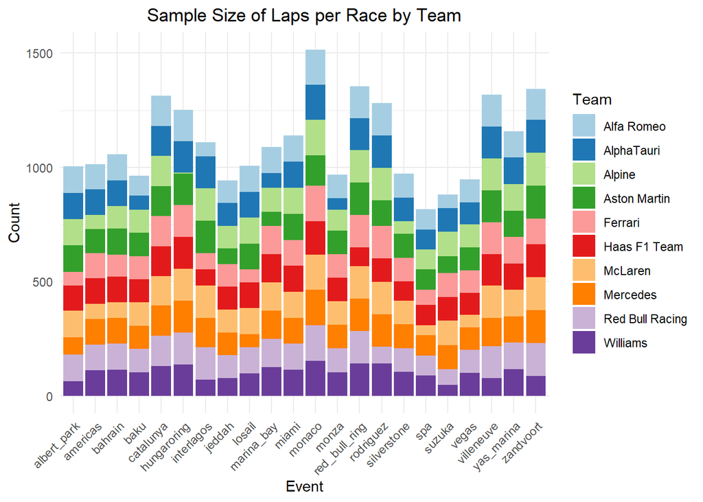

```r
ggplot(season_df, aes(x = event, fill = team)) +
  geom_bar(position = "stack") +
  labs(x = "Event", y = "Count", title = "Sample Size of Laps per Race by Team") +
  scale_fill_brewer(palette = "Paired", name = "Team") +
  theme_minimal() + theme(axis.text.x = element_text(angle = 45, hjust=1)) +
  theme(plot.title = element_text(hjust = 0.5))
```

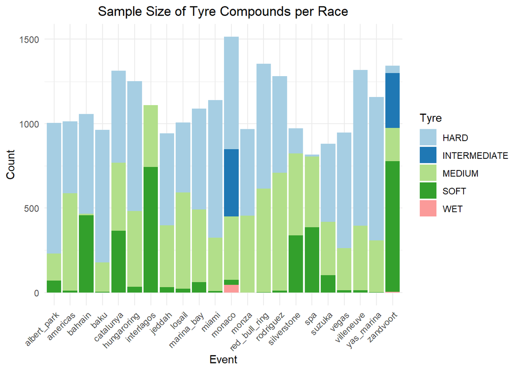

```r
ggplot(season_df, aes(x = event, fill = tyre)) +
  geom_bar(position = "stack") +
  labs(x = "Event", y = "Count", title = "Sample Size of Tyre Compounds per Race") +
  scale_fill_brewer(palette = "Paired", name = "Tyre") +
  theme_minimal() + theme(axis.text.x = element_text(angle = 45, hjust=1)) +
  theme(plot.title = element_text(hjust = 0.5))
```

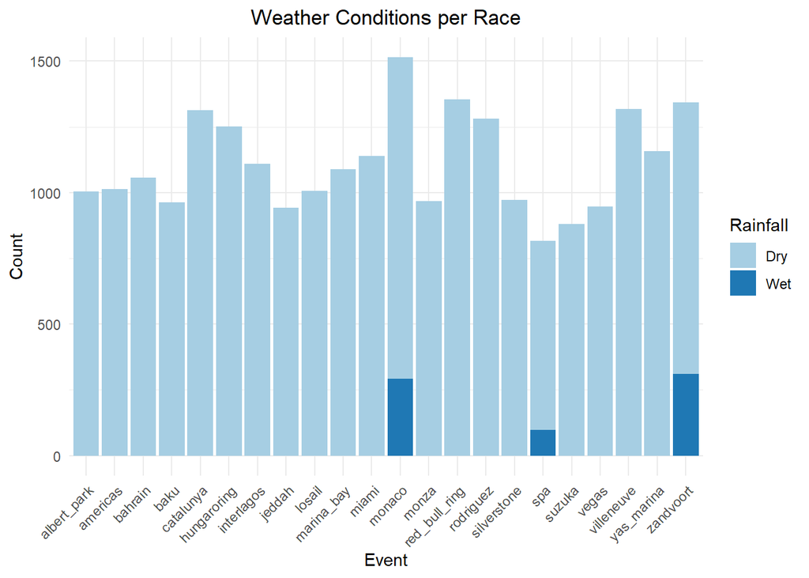

```r
ggplot(season_df, aes(x = event, fill = rainfall)) +
  geom_bar(position = "stack") +
  labs(x = "Event", y = "Count", title = "Weather Conditions per Race") +
  scale_fill_brewer(palette = "Paired", name = "Rainfall") +
  theme_minimal() + theme(axis.text.x = element_text(angle = 45, hjust=1)) +
  theme(plot.title = element_text(hjust = 0.5))
```

```r
# Need a new df with 8 variables, 5 rows, count of unique events with a value

value_counts <- season_df %>%
  pivot_longer(cols = c(traction, asphalt_grip, asphalt_abrasion, track_evol,
                    tyre_stress, braking, lateral, downforce), names_to = "Variable", values_to = "Value") %>%
  group_by(Variable, Value) %>%
  summarise(n = n_distinct(event), .groups = "drop") %>%  # Count unique events
  arrange(Variable, Value)

# Print result
print(value_counts)
```

```
## # A tibble: 36 × 3
##    Variable         Value     n
##    <chr>            <int> <int>
##  1 asphalt_abrasion     1     2
##  2 asphalt_abrasion     2     6
##  3 asphalt_abrasion     3     7
##  4 asphalt_abrasion     4     6
##  5 asphalt_abrasion     5     1
##  6 asphalt_grip         1     4
##  7 asphalt_grip         2     2
##  8 asphalt_grip         3    15
##  9 asphalt_grip         4     1
## 10 braking              2     5
## # ℹ 26 more rows
```

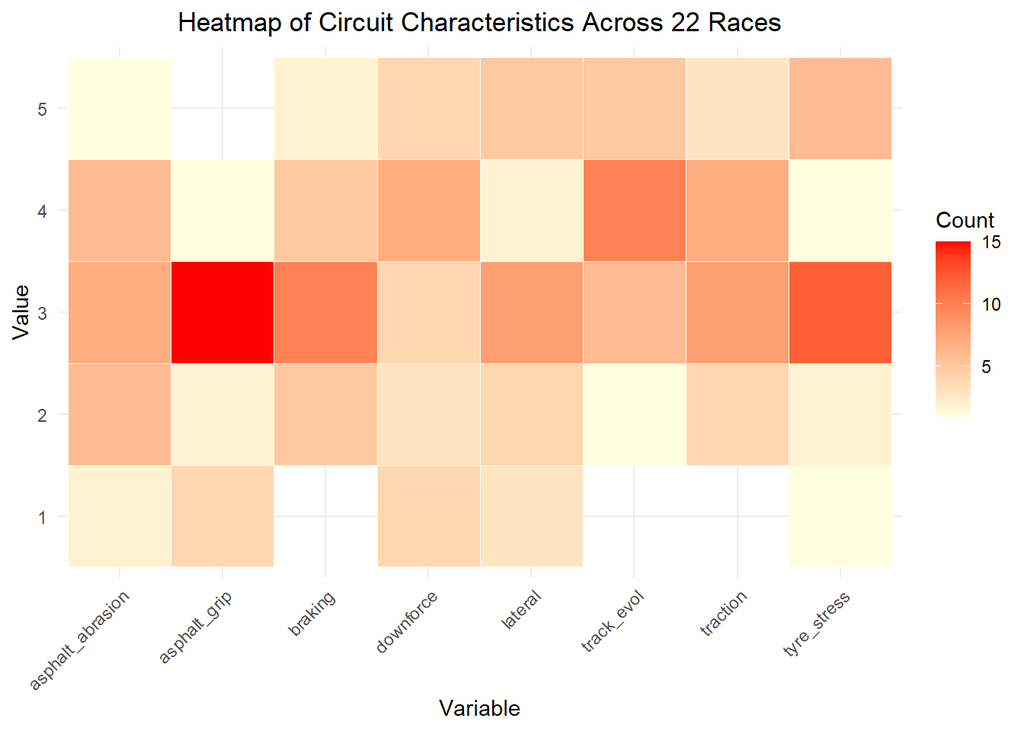

```r
ggplot(value_counts, aes(x = Variable, y = as.factor(Value), fill = n)) +
  geom_tile(color = "white") +
  scale_fill_gradient(low = "lightyellow", high = "red") +
  labs(title = "Heatmap of Circuit Characteristics Across 22 Races",
       x = "Variable",
       y = "Value",
       fill = "Count") +
  theme_minimal() +
  theme(axis.text.x = element_text(angle = 45, hjust=1)) +
  theme(plot.title = element_text(hjust=0.5))
```

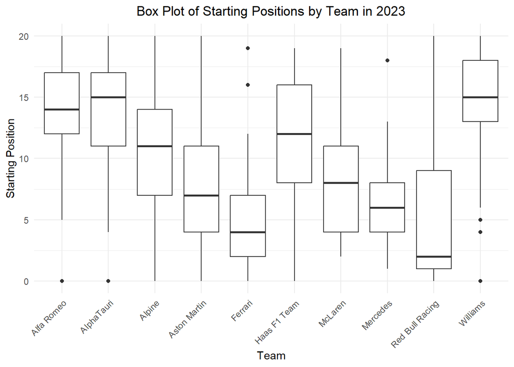

```r
# if pitstop is na
ggplot(data=season_df, mapping = aes(x = team, y = start_position)) +
  geom_boxplot() + theme(axis.text.x = element_text(angle = 45, hjust=1)) +
  labs(x = "Team", y = "Starting Position", title = "Box Plot of Starting Positions by Team in 2023") +
  theme_minimal() + theme(axis.text.x = element_text(angle = 45, hjust=1)) +
  theme(plot.title = element_text(hjust = 0.5))
```

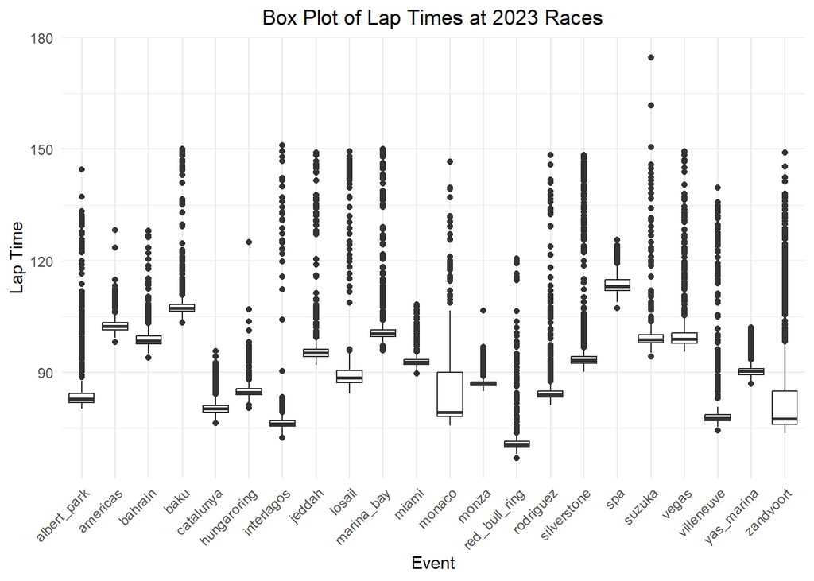

```r
# if pitstop is na
ggplot(data=subset(season_df, is.na(pitstop_duration)), mapping = aes(x = event, y = lap_time)) +
  geom_boxplot() + theme(axis.text.x = element_text(angle = 45, hjust=1)) +
  labs(x = "Event", y = "Lap Time", title = "Box Plot of Lap Times at 2023 Races") +
  theme_minimal() + theme(axis.text.x = element_text(angle = 45, hjust=1)) +
  theme(plot.title = element_text(hjust = 0.5))
```

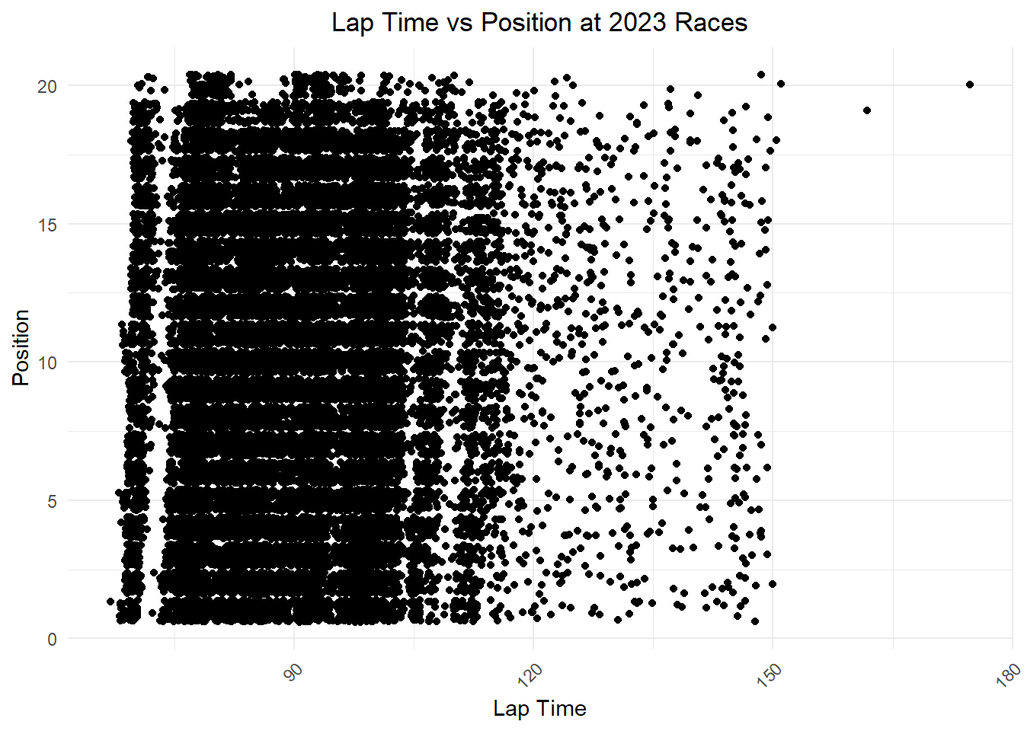

```r
# if pitstop is na
ggplot(data=subset(season_df, is.na(pitstop_duration)), mapping = aes(x = lap_time, y = position)) +
  geom_jitter() + theme(axis.text.x = element_text(angle = 45, hjust=1)) +
  labs(x = "Lap Time", y = "Position", title = "Lap Time vs Position at 2023 Races") +
  theme_minimal() + theme(axis.text.x = element_text(angle = 45, hjust=1)) +
  theme(plot.title = element_text(hjust = 0.5))
```

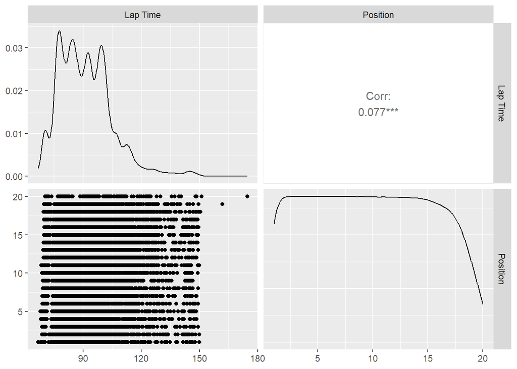

```r
ggpairs(season_df, columns = c("lap_time", "position"), columnLabels = c("Lap Time", "Position"))
```

## Missingness

```r
# Check how many wrong pitstop_duration values are there and which races they are present in

# Check for time-series-like string entries
time_like <- str_detect(season_df$pitstop_duration, "\\d+:\\d+\\.\\d+")
# Count occurrences
num_time_like <- sum(time_like)
# Check how many time-series-like entries there are per event
miss_pit_per_events <- season_df %>%
  filter(time_like) %>%
  group_by(event) %>%
  summarise(count = n(), .groups = "drop")

print(miss_pit_per_events)
```

```
## # A tibble: 7 × 2
##   event       count
##   <chr>       <int>
## 1 albert_park    49
## 2 interlagos     17
## 3 marina_bay      1
## 4 rodriguez      18
## 5 suzuka          1
## 6 villeneuve      1
## 7 zandvoort       9
```

It seems that only 7 events are affected by the wrong pitstop data format. Interestingly, for all those laps the lap_time variable is also missing, which seems to be an error or technology failure in collecting the timing data, with the entry being overwritten by a timestamp.

```r
# Get total number of pitstops per race to help deciding what to drop
total_pitstops <- season_df %>%
  filter(!is.na(pitstop_duration)) %>%
  group_by(event) %>%
  summarise(count = n(), .groups = "drop")
print(total_pitstops)
```

```
## # A tibble: 22 × 2
##    event       count
##    <chr>       <int>
##  1 albert_park    65
##  2 americas       36
##  3 bahrain        50
##  4 baku           23
##  5 catalunya      43
##  6 hungaroring    36
##  7 interlagos     67
##  8 jeddah         24
##  9 losail         54
## 10 marina_bay     25
## # ℹ 12 more rows
```

```r
# get the average of pitstops
mean(total_pitstops$count)
```

```
## [1] 40.5
```

In albert_park the incorrect format of pitstop_duration variable accounts for 75% of the pitstop datapoints. For interlagos and rodriguez, the incorrect datapoints are around 25% and 47% of the total pitstops. In Zaandvort 9 laps are affected, which makes for only around 11% of pitstops at that event. For races where this occurs only once, such as marina_bay, suzuka, villeneuve - this mistaken row of data will be dropped.

Setting an allowance of up to 20% pitstop_duration data missing, we disregard data from albert_park, interlagos, rodriguez in later analysis. For other events, this rows of data will be dropped as a data cleaning step.

```r
# # remove albert_park, interlagos, rodriguez
# season_df_filtered <- season_df %>% filter(!event %in% c("albert_park", "interlagos", "rodriguez"))

#find out the percentage of missing lap time data
sum(is.na(season_df$lap_time))/dim(season_df)[1]
```

```
## [1] 0.01833736
```

```r
#drop the missing lap_times as they account for less than 2% of the data
season_df_filtered <- season_df %>% filter(!is.na(lap_time))

# filter out Alpine at Hungaroring (only 1 or 2 laps per driver due to crash)
season_df_filtered <- season_df_filtered %>% filter(event != "hungaroring" | team != "Alpine")
```

```r
# list of levels of previous position
prev_pos_levels <- c("1",  "2" , "3", "4", "5" , "6",  "7",  "8",  "9",  "10", "11", "12", "13", "14", "15", "16", "17", "18", "19", "20", "0")
pos_levels <-  c("1",  "2" , "3", "4", "5" , "6",  "7",  "8",  "9",  "10", "11", "12", "13", "14", "15", "16", "17", "18", "19", "20")
```

```r
# Create an empty list to store each processed round
race_list <- list()

for (round in unique(season_df_filtered$event)) {
  print(round)
  race_df <- subset(season_df_filtered, event == round)

  # Convert pitstop_duration to numeric
  race_df$pitstop_duration <- as.numeric(race_df$pitstop_duration)

  # Make bins
  race_df$pitstop_duration <- cut(
    race_df$pitstop_duration,
    breaks = c(
      min(race_df$pitstop_duration, na.rm = TRUE),
      quantile(race_df$pitstop_duration, probs = c(.2, .4, .6, .8), na.rm=TRUE),
      max(race_df$pitstop_duration, na.rm = TRUE)
    ),
    ordered_result = TRUE,
    include.lowest = TRUE,
    labels = c("fastest_pit", "20", "40", "60", "80")
  )

  # Add "no_pitstop" to the factor levels for pitstop_duration
  race_df$pitstop_duration <- factor(
    race_df$pitstop_duration,
    levels = c("no_pitstop", levels(race_df$pitstop_duration))
  )

  # Replace all NA values with "no_pitstop"
  race_df <- race_df %>% replace_na(list(pitstop_duration = "no_pitstop"))

  # Lap time bins
  race_df$lap_time <- cut(race_df$lap_time,
                            breaks = c(min(race_df$lap_time, na.rm = TRUE),
                            quantile(race_df$lap_time,probs = c(.02, .05, .1, .15, .2, .3,.4,.5,.6, .7,.8, .85, .9, .95, .98),na.rm=TRUE),
                            max(race_df$lap_time, na.rm = TRUE)), include.lowest = TRUE, ordered_result = TRUE, labels = c("fastest", "02", "05", "10", "15", "20", "30","40","50","60", "70","80", "85", "90", "95", "98"))

  # Convert to factors or ordered factors
  race_df$driver <- factor(race_df$driver)
  race_df$team <- factor(race_df$team)
  race_df$tyre <- factor(race_df$tyre)
  race_df$rainfall <- factor(race_df$rainfall)


  # Make a variable for position on previous lap
  race_df <- race_df %>%
    mutate(previous_position = ifelse(lap_number == 1, start_position, shift(race_df$position, n=1, type="lag")))

  # Positions are ordered, quite self-explanatory reason
  race_df$previous_position <- factor(race_df$previous_position, ordered = TRUE, levels = prev_pos_levels)
  race_df$position <- factor(race_df$position, ordered = TRUE, levels = pos_levels)


  # Store the modified race_df in the list
  race_list[[round]] <- race_df
}
```

```
## [1] "albert_park"
## [1] "americas"
## [1] "bahrain"
## [1] "baku"
## [1] "catalunya"
## [1] "hungaroring"
## [1] "interlagos"
## [1] "jeddah"
## [1] "losail"
## [1] "marina_bay"
## [1] "miami"
## [1] "monaco"
## [1] "monza"
## [1] "red_bull_ring"
## [1] "rodriguez"
## [1] "silverstone"
## [1] "spa"
## [1] "suzuka"
## [1] "vegas"
## [1] "villeneuve"
```

```
## [1] "yas_marina"
## [1] "zandvoort"
```

```r
# Merge all processed race_df dataframes into a new full-season dataframe
full_season_df <- bind_rows(race_list)
```

```r
# Circuit characteristics
full_season_df$traction <- factor(full_season_df$traction, ordered = TRUE)
full_season_df$asphalt_grip <- factor(full_season_df$asphalt_grip, ordered = TRUE)
full_season_df$asphalt_abrasion <- factor(full_season_df$asphalt_abrasion, ordered = TRUE)
full_season_df$track_evol <- factor(full_season_df$track_evol, ordered = TRUE)
full_season_df$tyre_stress <- factor(full_season_df$tyre_stress, ordered = TRUE)
full_season_df$braking <- factor(full_season_df$braking, ordered = TRUE)
full_season_df$lateral <- factor(full_season_df$lateral, ordered = TRUE)
full_season_df$downforce <- factor(full_season_df$downforce, ordered = TRUE)

#Save each of the races to be removed as seperate dfs

interlagos_df <- full_season_df %>% filter(event =="interlagos")

albert_park_df <- full_season_df %>% filter(event =="albert_park")

rodriguez_df <- full_season_df %>% filter(event =="rodriguez")


# remove albert_park, interlagos, rodriguez
full_season_df <- full_season_df %>% filter(!event %in% c("albert_park", "interlagos", "rodriguez"))


# Choosing relevant variables
season23_full <- full_season_df %>%  dplyr::select(c( driver, lap_time,
                                tyre, team,
                                position, rainfall,
                                previous_position, pitstop_duration,
                                traction, asphalt_grip, asphalt_abrasion,
                                track_evol, tyre_stress, braking,
                                lateral, downforce
                                ))
```

```r
library(polycor)
polychor(season23_full$lap_time, season23_full$position)
```

```
## [1] 0.3497673
```

# Structure learning

## Blacklists and whitelists

Make a blacklist representing the natural temporal ordering of variables

```r
# Blacklist variables so that chronological order is kept
big_bl = matrix(c(
              "lap_time", "pitstop_duration",
              "lap_time", "tyre"
             ),
            ncol = 2, byrow = TRUE)

# Nothing from position
for (name in names(season23_full)){
  bl2 = matrix(c("position", name), ncol=2,
            dimnames =list(NULL,c("from","to")))
  big_bl = rbind(big_bl, bl2)
}


# Nothing to team
for (name in names(season23_full)){
  bl3 = matrix(c(name, "team"), ncol=2,
            dimnames =list(NULL,c("from","to")))
  big_bl = rbind(big_bl, bl3)
}

# Nothing to rainfall
for (name in names(season23_full)){
  bl3 = matrix(c(name, "rainfall"), ncol=2,
            dimnames =list(NULL,c("from","to")))
  big_bl = rbind(big_bl, bl3)
}

# Nothing to circuit characteristics from other variables
circuit_chars <- c("traction", "asphalt_grip", "asphalt_abrasion",
                                "track_evol", "tyre_stress", "braking",
                                "lateral", "downforce")
other_vars <- c("driver", "lap_time",
                                "tyre", "team", "rainfall",
                                "previous_position", "pitstop_duration")
for (name in names(season23_full)){
  for (circ in circuit_chars){
    bl4 = matrix(c(name, circ), ncol=2,
              dimnames =list(NULL,c("from","to")))
    big_bl = rbind(big_bl, bl4)
}}

big_bl
```

```
##        from                to
##   [1,] "lap_time"          "pitstop_duration"
##   [2,] "lap_time"          "tyre"
##   [3,] "position"          "driver"
##   [4,] "position"          "lap_time"
##   [5,] "position"          "tyre"
##   [6,] "position"          "team"
##   [7,] "position"          "position"
##   [8,] "position"          "rainfall"
##   [9,] "position"          "previous_position"
##  [10,] "position"          "pitstop_duration"
##  [11,] "position"          "traction"
##  [12,] "position"          "asphalt_grip"
##  [13,] "position"          "asphalt_abrasion"
##  [14,] "position"          "track_evol"
```

[output cut: 164 more lines]

```r
# Whitelist
wl = matrix(c(
              "previous_position", "position"
             ),
            ncol = 2, byrow = TRUE)
```

## IAMB

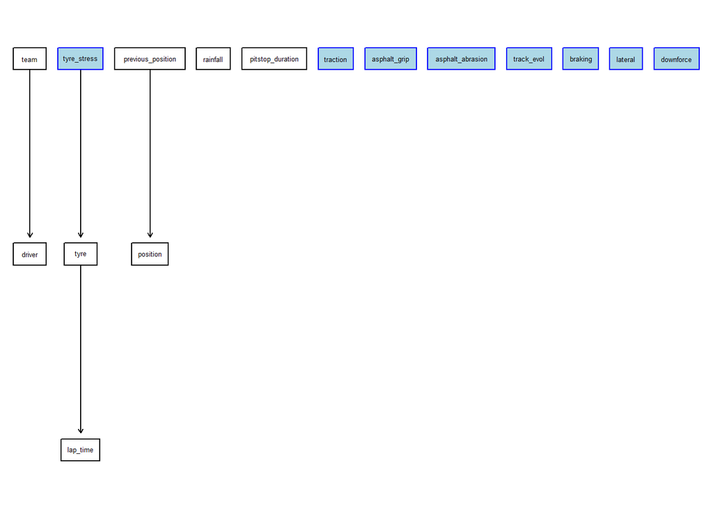

```r
season23_full.iamb =iamb(season23_full, blacklist = big_bl, whitelist = wl, test ='mi')
highlight = list(nodes = circuit_chars, col = "blue", fill = "lightblue")
graphviz.plot(season23_full.iamb, render = TRUE, highlight = highlight)
```

```r
# Choosing relevant variables
season23 <- full_season_df %>%  dplyr::select(c( driver, lap_time,
                                tyre, team,
                                position, rainfall,
                                previous_position, pitstop_duration,
                                traction, tyre_stress
                                ))

# New blacklist variables so that chronological order is kept
bl = matrix(c(
              "lap_time", "pitstop_duration",
              "lap_time", "tyre"
             ),
            ncol = 2, byrow = TRUE)

# Nothing from position
for (name in names(season23)){
  bl2 = matrix(c("position", name), ncol=2,
            dimnames =list(NULL,c("from","to")))
  bl = rbind(bl, bl2)
}


# Nothing to team
for (name in names(season23)){
  bl3 = matrix(c(name, "team"), ncol=2,
            dimnames =list(NULL,c("from","to")))
  bl = rbind(bl, bl3)
}

# Nothing to rainfall
for (name in names(season23)){
  bl3 = matrix(c(name, "rainfall"), ncol=2,
            dimnames =list(NULL,c("from","to")))
  bl = rbind(bl, bl3)
}

# Nothing to circuit characteristics from other variables
circuit_chars_select <- c("traction", "tyre_stress")

for (name in names(season23)){
  for (circ in circuit_chars_select){
    bl4 = matrix(c(name, circ), ncol=2,
              dimnames =list(NULL,c("from","to")))
    bl = rbind(bl, bl4)
}}

bl
```

```
##       from                to
##  [1,] "lap_time"          "pitstop_duration"
##  [2,] "lap_time"          "tyre"
##  [3,] "position"          "driver"
##  [4,] "position"          "lap_time"
##  [5,] "position"          "tyre"
##  [6,] "position"          "team"
##  [7,] "position"          "position"
##  [8,] "position"          "rainfall"
##  [9,] "position"          "previous_position"
## [10,] "position"          "pitstop_duration"
## [11,] "position"          "traction"
## [12,] "position"          "tyre_stress"
## [13,] "driver"            "team"
## [14,] "lap_time"          "team"
```

[output cut: 38 more lines]

```r
# Whitelist
wl = matrix(c(
              "previous_position", "position"
             ),
            ncol = 2, byrow = TRUE)
```

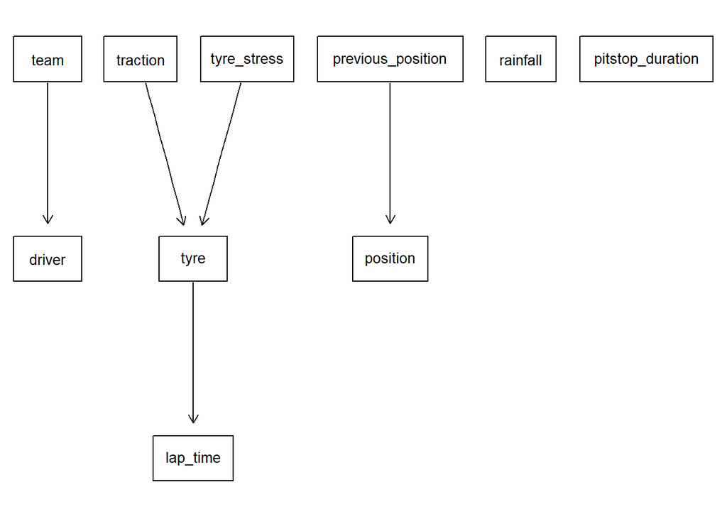

```r
season23.iamb =iamb(season23, blacklist = bl, whitelist = wl, test ='mi')
graphviz.plot(season23.iamb)
```

```r
score(season23.iamb, data = season23, type = "bic")
```

```
## [1] -278098.1
```

## Hill-climbing

Learning DAG using hill climbing and whitelists, blacklists

```r
# Use hill-climbing to determine the DAG with blacklisting
season23_full.hc =hc(season23_full, blacklist = big_bl, whitelist = wl)
```

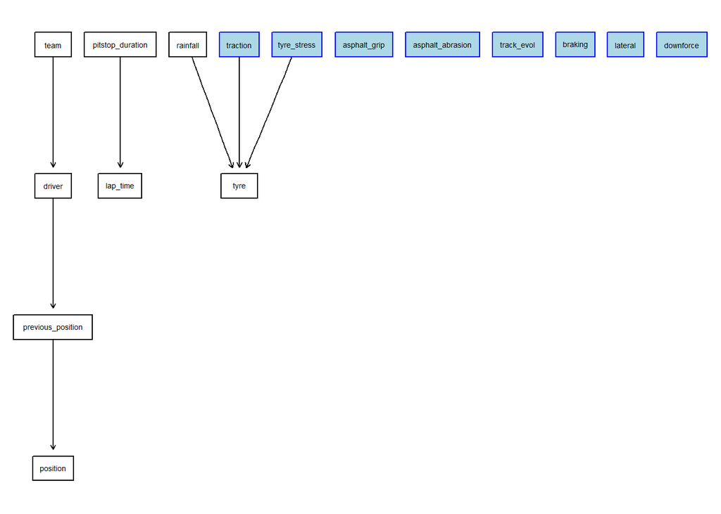

```r
highlight = list(nodes = circuit_chars, col = "blue", fill = "lightblue")
graphviz.plot(season23_full.hc, render = TRUE, highlight = highlight)
```

```r
score(season23_full.hc, data = season23_full, type = "bic")
```

```
## [1] -435574
```

```r
# Use hill-climbing to determine the DAG with blacklisting
season23.hc =hc(season23, blacklist = bl, whitelist = wl)
```

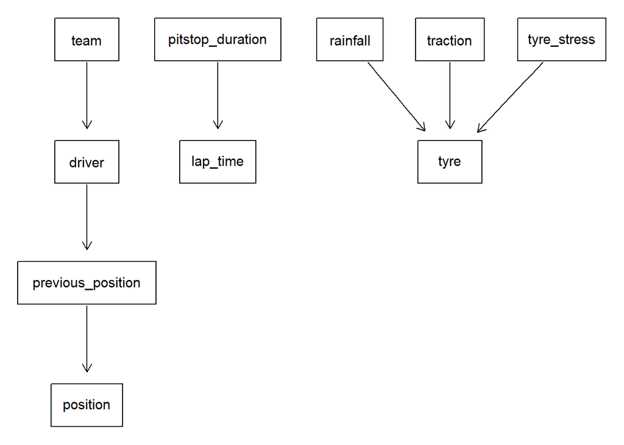

```r
graphviz.plot(season23.hc)
```

```r
score(season23.hc, data = season23, type = "bic")
```

```
## [1] -268864.6
```

Perform independence tests:

```r
# Does driver influence previous position?
ci.test("previous_position","driver", test = "mc-mi", data = season23)
```

```
##
##  Mutual Information (disc., MC)
##
## data:  previous_position ~ driver
## mc-mi = 22050, Monte Carlo samples = 5000, p-value < 2.2e-16
## alternative hypothesis: true value is greater than 0
```

```r
# Does pitstop_duration influence lap_time?
ci.test("lap_time", "pitstop_duration", test = "mc-jt", data = season23)
```

```
##
##  Jonckheere-Terpstra (MC)
##
## data:  lap_time ~ pitstop_duration
## mc-jt = 39.586, Monte Carlo samples = 5000, p-value < 2.2e-16
## alternative hypothesis: true value is not equal to 0
```

```r
# Does pitstop_duration influence lap_time given tyre?
ci.test("lap_time", "pitstop_duration", "tyre", test = "mc-mi", data = season23)
```

```
##
##  Mutual Information (disc., MC)
##
## data:  lap_time ~ pitstop_duration | tyre
## mc-mi = 2902.5, Monte Carlo samples = 5000, p-value < 2.2e-16
## alternative hypothesis: true value is greater than 0
```

```r
# Does tyre influence lap_time?
ci.test("lap_time","tyre", "pitstop_duration", test = "mc-mi", data = season23)
```

```
##
##  Mutual Information (disc., MC)
##
## data:  lap_time ~ tyre | pitstop_duration
## mc-mi = 2166, Monte Carlo samples = 5000, p-value < 2.2e-16
## alternative hypothesis: true value is greater than 0
```

```r
# Does rainfall influence tyre?
ci.test("tyre", "rainfall", c("traction", "tyre_stress"), test = "mc-mi", data = season23)
```

```
##
##  Mutual Information (disc., MC)
##
## data:  tyre ~ rainfall | traction + tyre_stress
## mc-mi = 799.31, Monte Carlo samples = 5000, p-value < 2.2e-16
## alternative hypothesis: true value is greater than 0
```

```r
# Does lap_time influence position?
ci.test("position", "lap_time", "previous_position", test = "mc-jt", data = season23)
```

```
##
##  Jonckheere-Terpstra (MC)
##
## data:  position ~ lap_time | previous_position
## mc-jt = 23.158, Monte Carlo samples = 5000, p-value < 2.2e-16
## alternative hypothesis: true value is not equal to 0
```

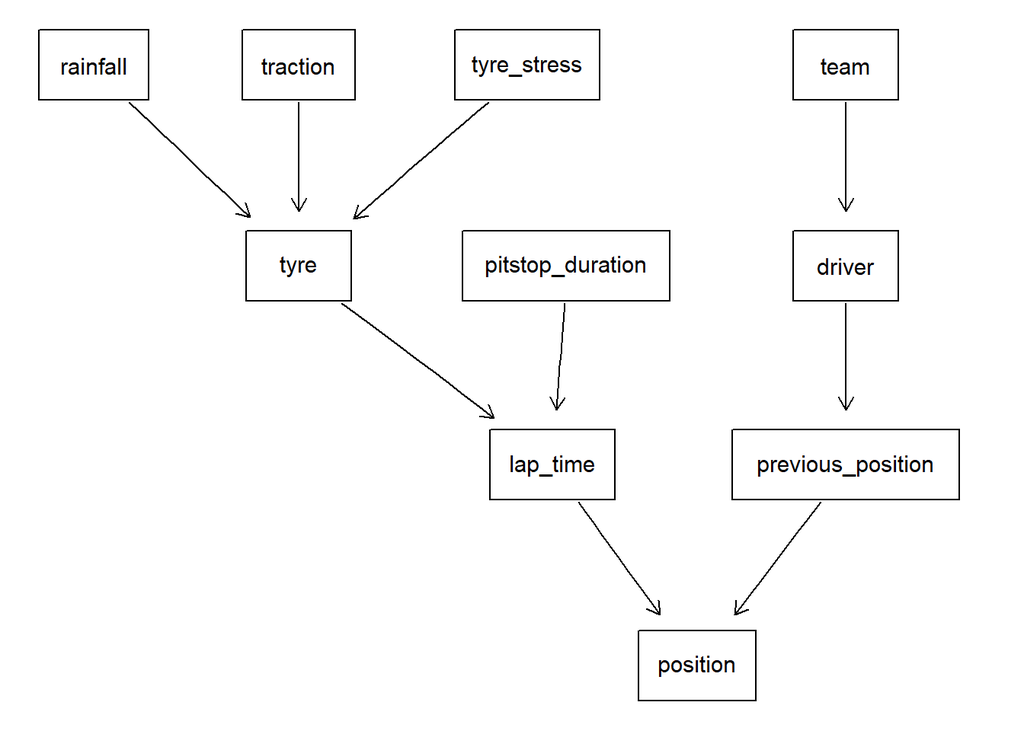

```r
tested_season23.hc = set.arc(season23.hc, from = "tyre", to = "lap_time")
tested_season23.hc = set.arc(tested_season23.hc, from = "lap_time", to = "position")
graphviz.plot(tested_season23.hc)
```

```r
score(tested_season23.hc, data = season23, type = "bic")
```

```
## [1] -296130.7
```

```r
arc.strength(tested_season23.hc, data = season23, criterion = "bic")
```

```
##                from                to     strength
## 1 previous_position          position -14933.81196
## 2              team            driver -46799.87322
## 3            driver previous_position  -8937.67824
## 4       tyre_stress              tyre  -1741.52215
## 5          traction              tyre   -768.76563
## 6  pitstop_duration          lap_time    412.43565
## 7          rainfall              tyre     -2.06756
## 8              tyre          lap_time    706.15928
## 9          lap_time          position  26559.95317
```

```r
arc.strength(tested_season23.hc, data = season23, criterion = "mi")
```

```
##                from                to      strength
## 1 previous_position          position  0.000000e+00
## 2              team            driver  0.000000e+00
## 3            driver previous_position  0.000000e+00
## 4       tyre_stress              tyre  0.000000e+00
## 5          traction              tyre  0.000000e+00
## 6  pitstop_duration          lap_time  0.000000e+00
## 7          rainfall              tyre 4.286093e-119
## 8              tyre          lap_time 7.790181e-255
## 9          lap_time          position  2.840024e-04
```

## Prediction

Use the deleted races for prediction (interlagos example)

```r
# Choosing relevant variables
int_pred <- interlagos_df %>%  dplyr::select(c( driver, lap_time,
                                tyre, team,
                                # position,
                                rainfall,
                                previous_position, pitstop_duration,
                                traction, tyre_stress
                                ))

# Ensure the levels match (some drivers were changed during the season)
levels(int_pred$driver) <- levels(season23$driver)

# Predict
season23.fit = bn.fit(tested_season23.hc, data = season23)
int.prediction = predict(season23.fit, data= int_pred, node = "position", method = "bayes-lw")
int.prediction
```

```
##    [1] 4    7    4    3    3    3    3    3    3    3    3    3    3    3
##   [15] 3    3    3    3    3    3    3    3    3    3    3    4    3    3
##   [29] 3    3    3    3    3    3    3    3    3    3    3    3    3    3
##   [43] 3    3    3    3    3    5    5    5    5    4    3    3    3    3
##   [57] 3    3    3    3    3    3    3    3    3    3    3    3    3    4
##   [71] 18   19   12   13   13   13   13   13   13   12   12   12   12   11
##   [85] 11   10   10   11   13   13   13   12   12   12   12   12   10   10
##   [99] 10   10   9    10   10   10   10   11   11   11   15   14   11   9
##  [113] 9    9    9    9    9    9    9    9    9    9    9    9    9    8
##  [127] 7    7    6    5    5    5    5    5    12   12   11   11   10   9
##  [141] 9    9    9    9    9    9    9    9    9    9    8    8    8    9
##  [155] 10   9    9    8    8    8    8    8    8    7    7    7    7    7
##  [169] 7    7    7    7    7    7    7    7    7    7    5    6    3    4
##  [183] 4    4    4    4    4    4    4    4    4    4    4    4    4    9
##  [197] 11   10   8    8    8    8    8    9    6    6    6    6    6    6
```

[output cut: 64 more lines]

```r
# Assess the predicitons
int.predicted.pos = predict(season23.fit, data= int_pred, node = "position", method = "bayes-lw")
predicted_values_numeric <- as.numeric(as.character(int.predicted.pos))
true_values_numeric <- as.numeric(as.character(interlagos_df$position))

mae <- mean(abs(predicted_values_numeric - true_values_numeric), na.rm = TRUE)
print(paste("MAE:", round(mae, 2)))
```

```
## [1] "MAE: 0.35"
```

```r
rmse <- sqrt(mean((predicted_values_numeric - true_values_numeric)^2, na.rm = TRUE))
print(paste("RMSE:", round(rmse, 2)))
```

```
## [1] "RMSE: 0.99"
```

Barcelona what-if prediction

```r
# Choosing relevant variables
bar_pred <- full_season_df %>% filter(event == "catalunya") %>%
  dplyr::select(c( driver, lap_time,
                                tyre, team,
                                # position,
                                rainfall,
                                previous_position, pitstop_duration,
                                traction, tyre_stress
                                ))

# Ensure the levels match (some drivers were changed during the season)
levels(bar_pred$driver) <- levels(season23$driver)

# Predict
season23.fit = bn.fit(tested_season23.hc, data = season23)
bar.prediction = predict(season23.fit, data= bar_pred, node = "position", method = "bayes-lw")
bar.prediction
```

```
##    [1] 18 17 16 16 16 16 16 17 16 15 13 12 12 12 11 10 19 20 19 19 19 19 19 18
##   [25] 18 17 17 16 16 16 16 16 17 17 17 17 17 19 19 19 18 18 18 17 17 17 17 17
##   [49] 17 17 17 16 16 16 16 16 16 16 16 16 16 16 16 16 16 8  6  6  6  6  6  6
##   [73] 7  7  7  7  7  7  6  6  5  4  4  4  5  10 9  9  9  9  9  9  9  8  8  8
##   [97] 9  9  9  8  6  6  6  6  6  6  6  5  5  5  10 10 10 9  8  8  7  7  7  7
##  [121] 7  7  7  7  7  7  7  7  7  7  7  16 18 17 17 17 19 19 19 19 18 18 17 17
##  [145] 17 18 19 19 17 16 16 17 17 17 17 17 16 16 15 15 15 15 15 15 15 16 16 16
##  [169] 16 16 18 20 20 20 20 20 20 20 20 20 20 20 19 19 20 20 20 20 20 20 20 20
##  [193] 19 19 19 19 14 16 15 15 15 15 15 15 14 19 19 18 19 19 19 18 18 16 14 15
##  [217] 14 14 14 15 14 14 15 14 14 14 14 14 14 14 14 12 11 10 13 17 17 16 15 15
##  [241] 14 14 14 14 14 14 14 14 14 14 14 14 14 14 14 14 14 14 14 14 14 10 15 14
##  [265] 14 14 14 14 14 13 13 11 10 10 10 9  8  7  6  6  7  16 15 15 14 13 13 12
##  [289] 12 12 12 12 12 12 12 12 10 8  8  8  9  14 14 13 13 12 12 12 12 11 11 11
##  [313] 11 11 11 11 11 11 11 11 11 11 11 11 11 11 11 4  4  4  4  4  4  4  4  3
##  [337] 3  3  3  3  3  3  2  2  2  2  2  2  2  2  2  2  5  4  3  2  2  2  2  2
```

[output cut: 41 more lines]

```r
# Choosing relevant variables
cota_pred <- full_season_df %>% filter(event == "americas") %>%
  dplyr::select(c( driver, lap_time,
                                tyre, team,
                                rainfall,
                                pitstop_duration,
                                previous_position,
                                traction, tyre_stress
                                ))

# filter for hamilton, change his tyre at lap 39 (row 255 of the df)
cota_pred <- cota_pred %>%
  mutate(tyre = if_else(driver == "HAM" & row_number() >= 255, "HARD", tyre))

#Turn back into factor
cota_pred$tyre <- factor(cota_pred$tyre, levels = levels(full_season_df$tyre))
# Ensure the levels match (some drivers were changed during the season)
levels(cota_pred$driver) <- levels(season23$driver)
```

```r
# Predict
cota.prediction = predict(season23.fit, data= subset(cota_pred, driver == "HAM")[39:nrow(subset(cota_pred, driver == "HAM")),], node = "position", method = "bayes-lw")
cota.prediction
```

```
##  [1] 1 4 4 4 4 3 3 3 3 3 3 2 2 2 2 2 2 2
## 20 Levels: 1 < 2 < 3 < 4 < 5 < 6 < 7 < 8 < 9 < 10 < 11 < 12 < 13 < ... < 20
```

Singapore: would Russell overtake on the final lap if he didn’t crash?

```r
# Choosing relevant variables
sin_pred <- full_season_df %>% filter(event == "marina_bay") %>%
  dplyr::select(c( driver, lap_time,
                                tyre, team,
                                rainfall,
                                pitstop_duration,
                                previous_position,
                                traction, tyre_stress
                                ))
# Ensure the levels match (some drivers were changed during the season)
levels(sin_pred$driver) <- levels(season23$driver)

# Predict
sin.prediction = predict(season23.fit, data= subset(sin_pred, driver == "RUS")[nrow(subset(sin_pred, driver == "RUS")),], node = "position", method = "bayes-lw")
sin.prediction
```

```
## [1] 3
## 20 Levels: 1 < 2 < 3 < 4 < 5 < 6 < 7 < 8 < 9 < 10 < 11 < 12 < 13 < ... < 20
```

```r
# filter for hamilton, change his tyre at lap 39 (row 255 of the df)
sin_pred_fast <- sin_pred %>%
  mutate(lap_time = if_else(driver == "RUS" & row_number() >= 820, "fastest", lap_time))
sin_pred_fast$lap_time <- factor(sin_pred_fast$lap_time, levels = levels(full_season_df$lap_time))

sin.prediction_f = predict(season23.fit, data= subset(sin_pred, driver == "RUS")[nrow(subset(sin_pred, driver == "RUS")),], node = "position", method = "bayes-lw")
sin.prediction_f
```

```
## [1] 3
## 20 Levels: 1 < 2 < 3 < 4 < 5 < 6 < 7 < 8 < 9 < 10 < 11 < 12 < 13 < ... < 20
```